# Práctica Evaluada III - Regresión Logística

Máster en Análisis Político y Electoral

Francisco Javier Ramírez Leiva

15 de diciembre, 2020

##### Características del ejercicio

**Entregable:** El ejercicio se entregará a través de Aula Global. Se admitirán los siguientes tipos de ficheros:

- HTLM
- Rmd ejecutable y comentado (-1 punto)

**Duración máxima**: 2h 30min

**Puntación máxima**: El ejercicio supone un 25% de la nota final de la asignatura

**Realización**:Usando el dataset adjunto resuelve los ejercicios propuestos. Recuerda:

- ```
  Evita usar código redundante
  ```

- ```
  Las explicaciones breves pero exhaustivas. Razona tus decisiones siempre que el ejercicio lo requiera.
  ```

- ```
  Puedes usar tus apuntes, libros e incluso consultar información en internet.
  ```

- ```
  __No está permitido__ comunicarse con terceros durante el exámen por ningún medio (e-mail, teléfono, etc)
  ```

**¡Suerte!**

#### Librerías

```r
library(MASS)
library(rms)
library(lmtest)
library(margins)
library(ROCR)
library(caret)
library(ggplot2)
```

#### Lectura del set de datos. Crea el data.frame “data” a partir del fichero MD

```r
library(haven)
cis2020 <- read_sav("3298.sav")
View(cis2020)
```

# BLOQUE 1: LIMPIEZA DE VARIABLES Y ESTIMACIÓN DE LOS MODELOS (2,5 puntos)

## Preparación de las variables

### Variables dependientes

VD1: Opinión sobre el Gobierno de España (P15_3)

```r
cis2020$opi_gob<- cis2020$P15_3
cis2020$opi_gob[cis2020$opi_gob==1]<-1
cis2020$opi_gob[cis2020$opi_gob>1 & cis2020$opi_gob<=3]<-0
cis2020$opi_gob[cis2020$opi_gob>=7]<-NA
cis2020$opi_gob<- factor(cis2020$opi_gob,
                         levels = c(0,1),
                         labels = c("igual o peor","mejor"))
```

VD2: Opinión sobre el Ejército (P15_2)

```r
cis2020$opi_eje<- cis2020$P15_2
cis2020$opi_eje[cis2020$opi_eje==1]<-1
cis2020$opi_eje[cis2020$opi_eje>1 & cis2020$opi_eje<=3]<-0
cis2020$opi_eje[cis2020$opi_eje>=7]<-NA
cis2020$opi_eje<- factor(cis2020$opi_eje,
                         levels = c(0,1),
                         labels = c("igual o peor","mejor"))
```

### Variables independientes

Edad

```r
cis2020$edad<- cis2020$EDAD
summary(cis2020$edad)
```

```
##    Min. 1st Qu.  Median    Mean 3rd Qu.    Max.
##    18.0    38.0    50.0    50.5    64.0    90.0
```

No encontramos valores de 99 por lo tanto no tenemos que mandar nada a NA

Género

```r
cis2020$hombre<- cis2020$SEXO
cis2020$hombre[cis2020$hombre==1]<-1
cis2020$hombre[cis2020$hombre==2]<-0
cis2020$hombre<- factor(cis2020$hombre,
                        levels = c(0,1),
                        labels = c("mujer","hombre"))
```

Ideología (ESCIDEOL, P29)

```r
cis2020$ideol<- cis2020$ESCIDEOL
cis2020$ideol[cis2020$ideol>10]<-NA
summary(cis2020$ideol)
```

```
##    Min. 1st Qu.  Median    Mean 3rd Qu.    Max.    NA's
##    1.00    3.00    5.00    4.65    6.00   10.00     461
```

Clase social subjetiva (CLASESUB, p35a)

```r
cis2020$clase<- cis2020$CLASESUB
cis2020$clase[cis2020$clase==1]<-1
cis2020$clase[cis2020$clase==2]<-2
cis2020$clase[cis2020$clase==3]<-3
cis2020$clase[cis2020$clase==4]<-4
cis2020$clase[cis2020$clase==5]<-3
cis2020$clase[cis2020$clase>=6]<-NA
cis2020$clase<- factor(cis2020$clase,
                       levels = c(1,2,3,4),
                       labels = c("alta","media","baja","obrera"))
```

Miedo a enfermar (P3_1)

```r
cis2020$miedo_enf<- cis2020$P3_1
cis2020$miedo_enf[cis2020$miedo_enf==1]<-1
cis2020$miedo_enf[cis2020$miedo_enf==2]<-0
cis2020$miedo_enf[cis2020$miedo_enf>=8]<-NA
cis2020$miedo_enf<-factor(cis2020$miedo_enf,
                          levels = c(0,1),
                          labels = c("no","si"))
```

Miedo por la posibilidad de poder perder su empleo personal o el de algún/a familiar (P3_5)

```r
cis2020$perder_emp<- cis2020$P3_5
cis2020$perder_emp[cis2020$perder_emp==1]<-1
cis2020$perder_emp[cis2020$perder_emp==2]<-0
cis2020$perder_emp[cis2020$perder_emp>=8]<-NA
cis2020$perder_emp<-factor(cis2020$perder_emp,
                          levels = c(0,1),
                          labels = c("no","si"))
```

## Estimación de los modelos

### MODELO 1: Demográfico

```r
myvars <- c("opi_gob", "opi_eje", "edad", "hombre", "ideol", "clase","miedo_enf","perder_emp")
data<-as.data.frame(cis2020[myvars])
data<- na.omit(data)
dim(data)
```

```
## [1] 1890    8
```

```r
m.1 <- glm(opi_gob ~ edad + hombre, data = data, family = "binomial")
summary(m.1)
```

```
##
## Call:
## glm(formula = opi_gob ~ edad + hombre, family = "binomial", data = data)
##
## Deviance Residuals:
##     Min       1Q   Median       3Q      Max
## -0.9836  -0.7257  -0.6479  -0.5463   2.0387
##
## Coefficients:
##               Estimate Std. Error z value Pr(>|z|)
## (Intercept)  -2.297231   0.205089 -11.201  < 2e-16 ***
## edad          0.019597   0.003701   5.296 1.19e-07 ***
## hombrehombre  0.058800   0.113148   0.520    0.603
## ---
## Signif. codes:  0 '***' 0.001 '**' 0.01 '*' 0.05 '.' 0.1 ' ' 1
##
## (Dispersion parameter for binomial family taken to be 1)
##
##     Null deviance: 1969.2  on 1889  degrees of freedom
## Residual deviance: 1940.3  on 1887  degrees of freedom
## AIC: 1946.3
##
## Number of Fisher Scoring iterations: 4
```

```r
m.1a <- glm(opi_eje ~ edad + hombre, data = data, family = "binomial")
summary(m.1a)
```

```
##
## Call:
## glm(formula = opi_eje ~ edad + hombre, family = "binomial", data = data)
##
## Deviance Residuals:
##     Min       1Q   Median       3Q      Max
## -1.5728  -1.3495   0.9312   0.9923   1.1097
##
## Coefficients:
##               Estimate Std. Error z value Pr(>|z|)
## (Intercept)   0.174589   0.163197   1.070  0.28471
## edad          0.008083   0.003102   2.605  0.00918 **
## hombrehombre -0.158600   0.095201  -1.666  0.09572 .
## ---
## Signif. codes:  0 '***' 0.001 '**' 0.01 '*' 0.05 '.' 0.1 ' ' 1
##
## (Dispersion parameter for binomial family taken to be 1)
##
##     Null deviance: 2514.8  on 1889  degrees of freedom
## Residual deviance: 2505.4  on 1887  degrees of freedom
## AIC: 2511.4
##
## Number of Fisher Scoring iterations: 4
```

En el modelo m.1 referente al gobierno, solo vemos que la edad es estadísticamente significativo para la opinión del gobierno, esto lo vemos por los asteriscos y por el valor p que es inferior a 0.001, por lo que podríamos rechazar la H0 al 99.9%. El z valor esá por encima de 3.27.

En el modelo m.1a referente al ejército, solo vemos que la edad es estadísticamente significativo para la opínión sobre el ejercito, esto lo vemos por la marca de los asteríscos y por los valores de p y z que están, el primero por encima de 0.001 y el segundo entre los intervalos de confianza, por lo que podríamos rechazar la hipótesis nula al 99%

### MODELO 2: Socioeconómico

```r
m.2 <- glm(opi_gob ~ edad + hombre + ideol + clase, data = data, family = "binomial")
summary(m.2)
```

```
##
## Call:
## glm(formula = opi_gob ~ edad + hombre + ideol + clase, family = "binomial",
##     data = data)
##
## Deviance Residuals:
##     Min       1Q   Median       3Q      Max
## -1.5632  -0.6753  -0.4742  -0.1943   2.7252
##
## Coefficients:
##              Estimate Std. Error z value Pr(>|z|)
## (Intercept)  -0.55952    0.32933  -1.699   0.0893 .
## edad          0.02173    0.00402   5.406 6.46e-08 ***
## hombrehombre  0.11640    0.12333   0.944   0.3453
## ideol        -0.47986    0.03423 -14.017  < 2e-16 ***
## clasemedia    0.00655    0.23968   0.027   0.9782
## clasebaja     0.11282    0.25679   0.439   0.6604
## claseobrera   0.36131    0.27656   1.306   0.1914
## ---
## Signif. codes:  0 '***' 0.001 '**' 0.01 '*' 0.05 '.' 0.1 ' ' 1
##
## (Dispersion parameter for binomial family taken to be 1)
##
##     Null deviance: 1969.2  on 1889  degrees of freedom
## Residual deviance: 1663.2  on 1883  degrees of freedom
## AIC: 1677.2
##
## Number of Fisher Scoring iterations: 5
```

```r
m.2a <- glm(opi_eje ~ edad + hombre + ideol + clase, data = data, family = "binomial")
summary(m.2a)
```

```
##
## Call:
## glm(formula = opi_eje ~ edad + hombre + ideol + clase, family = "binomial",
##     data = data)
##
## Deviance Residuals:
##     Min       1Q   Median       3Q      Max
## -1.9846  -1.2606   0.8196   0.9867   1.4263
##
## Coefficients:
##               Estimate Std. Error z value Pr(>|z|)
## (Intercept)  -0.715336   0.257719  -2.776  0.00551 **
## edad          0.008597   0.003169   2.713  0.00667 **
## hombrehombre -0.197536   0.097390  -2.028  0.04253 *
## ideol         0.176892   0.022815   7.753 8.96e-15 ***
## clasemedia    0.129171   0.177788   0.727  0.46750
## clasebaja    -0.064351   0.194374  -0.331  0.74060
## claseobrera   0.168344   0.220979   0.762  0.44618
## ---
## Signif. codes:  0 '***' 0.001 '**' 0.01 '*' 0.05 '.' 0.1 ' ' 1
##
## (Dispersion parameter for binomial family taken to be 1)
##
##     Null deviance: 2514.8  on 1889  degrees of freedom
## Residual deviance: 2436.1  on 1883  degrees of freedom
## AIC: 2450.1
##
## Number of Fisher Scoring iterations: 4
```

En el modelo m.2 referente al gobierno, encotramos la significatividad estadística de la edad y ahora también la ideología.

### MODELO 3: Full-model

```r
m.3 <- glm(opi_gob ~ edad + hombre + ideol + clase + miedo_enf + perder_emp, data = data, family = "binomial")
summary(m.3)
```

```
##
## Call:
## glm(formula = opi_gob ~ edad + hombre + ideol + clase + miedo_enf +
##     perder_emp, family = "binomial", data = data)
##
## Deviance Residuals:
##     Min       1Q   Median       3Q      Max
## -1.6160  -0.6787  -0.4731  -0.1941   2.7623
##
## Coefficients:
##              Estimate Std. Error z value Pr(>|z|)
## (Intercept)  -0.63326    0.34417  -1.840   0.0658 .
## edad          0.02155    0.00406   5.308 1.11e-07 ***
## hombrehombre  0.12482    0.12393   1.007   0.3138
## ideol        -0.48123    0.03436 -14.006  < 2e-16 ***
## clasemedia    0.01219    0.24087   0.051   0.9597
## clasebaja     0.10364    0.25934   0.400   0.6894
## claseobrera   0.37038    0.27860   1.329   0.1837
## miedo_enfsi   0.22539    0.12755   1.767   0.0772 .
## perder_empsi -0.08251    0.13024  -0.634   0.5264
## ---
## Signif. codes:  0 '***' 0.001 '**' 0.01 '*' 0.05 '.' 0.1 ' ' 1
##
## (Dispersion parameter for binomial family taken to be 1)
##
##     Null deviance: 1969.2  on 1889  degrees of freedom
## Residual deviance: 1660.0  on 1881  degrees of freedom
## AIC: 1678
##
## Number of Fisher Scoring iterations: 5
```

```r
m.3a <- glm(opi_eje ~ edad + hombre + ideol + clase + miedo_enf + perder_emp, data = data, family = "binomial")
summary(m.3a)
```

```
##
## Call:
## glm(formula = opi_eje ~ edad + hombre + ideol + clase + miedo_enf +
##     perder_emp, family = "binomial", data = data)
##
## Deviance Residuals:
##     Min       1Q   Median       3Q      Max
## -2.0033  -1.2523   0.7925   0.9857   1.5741
##
## Coefficients:
##               Estimate Std. Error z value Pr(>|z|)
## (Intercept)  -1.024834   0.272111  -3.766 0.000166 ***
## edad          0.009580   0.003207   2.987 0.002814 **
## hombrehombre -0.160151   0.098243  -1.630 0.103070
## ideol         0.172488   0.022933   7.521 5.42e-14 ***
## clasemedia    0.095776   0.179007   0.535 0.592622
## clasebaja    -0.142898   0.196611  -0.727 0.467344
## claseobrera   0.107461   0.223152   0.482 0.630117
## miedo_enfsi   0.267371   0.099415   2.689 0.007157 **
## perder_empsi  0.240740   0.103675   2.322 0.020230 *
## ---
## Signif. codes:  0 '***' 0.001 '**' 0.01 '*' 0.05 '.' 0.1 ' ' 1
##
## (Dispersion parameter for binomial family taken to be 1)
##
##     Null deviance: 2514.8  on 1889  degrees of freedom
## Residual deviance: 2421.3  on 1881  degrees of freedom
## AIC: 2439.3
##
## Number of Fisher Scoring iterations: 4
```

En el modelo 3 referente a la opinión del gobierno, tanto edad como ideología son relevantes estadísticamente para nuestro modelo.

# BLOQUE 2: RESPUESTAS

## RESPUESTA 1 (1 punto)

Añade los chunck que sean necesarios

```r
coef(m.3a)
```

```
##  (Intercept)         edad hombrehombre        ideol   clasemedia    clasebaja
## -1.024834358  0.009580461 -0.160151125  0.172487962  0.095775658 -0.142898393
##  claseobrera  miedo_enfsi perder_empsi
##  0.107461448  0.267370547  0.240739734
```

- **Edad**: la edad en esta ocasión en positiva, lo que significa que por cada año que la edad de una persona aumenta, el logaritmo de probabilidad de opinar sobre el ejército aumenta en 0.009580461, manteniendo todas las variables constantes.
- **Sexo**: el sexo en esta ocasión en negativo, lo que significa que el logaritmo de probabilidad de opinar del ejército en los hombres frente a las mujeres dismuye en -0.160151125, manteniendo todas las variables constantes.
- **Ideología**: la ideología en esta ocasión es positiva, lo que significa que por cada punto que aumenta la ideología de una persona en la escala ideológica, el logaritmo de probabilidad de opinar del ejército aumenta en 0.172487962, manteniendo todas las variables constantes.
- **Clase media**: es positiva, en este caso el logaritmo de probabilidad de valorar al ejército es 0.095775658 mayor que en la clase alta.manteniendo todas las variables constantes.
- **Clase baja**: es negativa, en este caso el logaritmo de probabilidad de valorar al ejército es 0.142898393 menor que en la clase alta, manteniendo todas las variables constantes.
- **Clase obrera**: es positiva, en este caso el logaritmo de probabilidad de valorar al ejército es 0.107461448 mayor que en la clase alta, manteniendo todas las variables constantes.
- **Miedo a enfermar**: en este caso es positivo, lo que demuestra que el logaritmo de probabilidad de opinar del ejército es mejor en 0.267370547 en aquellas personas con miedo a enfermar de covid frente a las sin miedo a enfermar de covid, manteniendo todas las variables constantes.
- **Miedo a perder el empleo**: en este caso es positiva, lo que demuestra que el logaritmo de probabilidad de opinar del ejercito es mejor en 0.240739734 en aquellas personas con miedo a perder el empleo frente a las sin miedo a perder el empleo, manteniendo todas las variables constantes.

## RESPUESTA 2 (2 puntos)

Añade los chunck que sean necesarios

```r
exp(cbind(OR = coef(m.3), confint(m.3)))
```

```
##                     OR     2.5 %    97.5 %
## (Intercept)  0.5308602 0.2680794 1.0351438
## edad         1.0217837 1.0137287 1.0299990
## hombrehombre 1.1329436 0.8889094 1.4452655
## ideol        0.6180205 0.5770662 0.6602993
## clasemedia   1.0122605 0.6391130 1.6476827
## clasebaja    1.1092028 0.6734751 1.8664716
## claseobrera  1.4482777 0.8449485 2.5248627
## miedo_enfsi  1.2528051 0.9767442 1.6108353
## perder_empsi 0.9208045 0.7139449 1.1899022
```

Como vemos con los Odds Ratio, tanto la clase obrera como el miedo a enfermar pues tienen los valores positivos y más altos, lo que nos muestra que tiene más impacto sobre la valoración del gobierno y sería las variables que yo seleccionaría para implementar políticas, enfoncado una campaña de política hacía la clase obrera trabajadora con miedo a enfermar.

## RESPUESTA 3 (2 puntos)

Añade los chunck que sean necesarios

```r
margins_gobierno <- margins(m.3)
summary(margins_gobierno)
```

```
##        factor     AME     SE        z      p   lower   upper
##     clasebaja  0.0146 0.0360   0.4041 0.6862 -0.0560  0.0851
##    clasemedia  0.0017 0.0331   0.0507 0.9596 -0.0632  0.0665
##   claseobrera  0.0549 0.0405   1.3549 0.1754 -0.0245  0.1343
##          edad  0.0030 0.0006   5.4405 0.0000  0.0019  0.0041
##  hombrehombre  0.0176 0.0174   1.0090 0.3130 -0.0166  0.0517
##         ideol -0.0678 0.0040 -16.7765 0.0000 -0.0758 -0.0599
##   miedo_enfsi  0.0315 0.0177   1.7849 0.0743 -0.0031  0.0661
##  perder_empsi -0.0117 0.0185  -0.6305 0.5283 -0.0480  0.0246
```

Para la campaña del gobierno, el AME nos muestra un efecto de la edad de 0.0030

```r
margins_ejercito<- margins(m.3a)
summary(margins_ejercito)
```

```
##        factor     AME     SE       z      p   lower  upper
##     clasebaja -0.0328 0.0449 -0.7312 0.4647 -0.1208 0.0552
##    clasemedia  0.0215 0.0405  0.5311 0.5954 -0.0579 0.1009
##   claseobrera  0.0241 0.0501  0.4811 0.6304 -0.0741 0.1223
##          edad  0.0022 0.0007  3.0135 0.0026  0.0008 0.0036
##  hombrehombre -0.0360 0.0220 -1.6335 0.1024 -0.0792 0.0072
##         ideol  0.0388 0.0049  7.9644 0.0000  0.0292 0.0483
##   miedo_enfsi  0.0606 0.0226  2.6816 0.0073  0.0163 0.1049
##  perder_empsi  0.0547 0.0237  2.3090 0.0209  0.0083 0.1011
```

En el caso de la campaña para el ejército, el AME no muestra un efecto de la edad de 0.0022

```r
summary(margins_gobierno$dydx_edad)
```

```
##      Min.   1st Qu.    Median      Mean   3rd Qu.      Max.
## 0.0001428 0.0017250 0.0030065 0.0030374 0.0045273 0.0053875
```

```r
summary(margins_ejercito$dydx_edad)
```

```
##     Min.  1st Qu.   Median     Mean  3rd Qu.     Max.
## 0.001054 0.002029 0.002252 0.002154 0.002362 0.002395
```

## RESPUESTA 4 (2 puntos)

Añade los chunck que sean necesarios

```r
summary(data)
```

```
##          opi_gob             opi_eje          edad          hombre
##  igual o peor:1483   igual o peor: 723   Min.   :18.00   mujer : 889
##  mejor       : 407   mejor       :1167   1st Qu.:37.00   hombre:1001
##                                          Median :48.00
##                                          Mean   :48.34
##                                          3rd Qu.:60.00
##                                          Max.   :90.00
##      ideol           clase      miedo_enf perder_emp
##  Min.   : 1.000   alta  : 162   no: 790   no: 675
##  1st Qu.: 3.000   media :1093   si:1100   si:1215
##  Median : 5.000   baja  : 423
##  Mean   : 4.676   obrera: 212
##  3rd Qu.: 6.000
##  Max.   :10.000
```

```r
set.seed(123)
index <- 1:nrow(data)
porc_test <- 0.40
testindex <- sample(index, trunc(length(index)*porc_test))
train.data <- data[-testindex,]
test.data <- data[testindex,]

clase_real1 <- test.data$opi_gob

modelo.3 <- glm(opi_gob ~ edad + hombre + ideol + clase + miedo_enf + perder_emp, data = train.data, family = "binomial")

predict1<- predict(modelo.3, newdata=test.data, type="response")
head(predict1)
```

```
##        618        699        279        807        308       1397
## 0.06765016 0.20348697 0.08025467 0.07320697 0.15382320 0.25752806
```

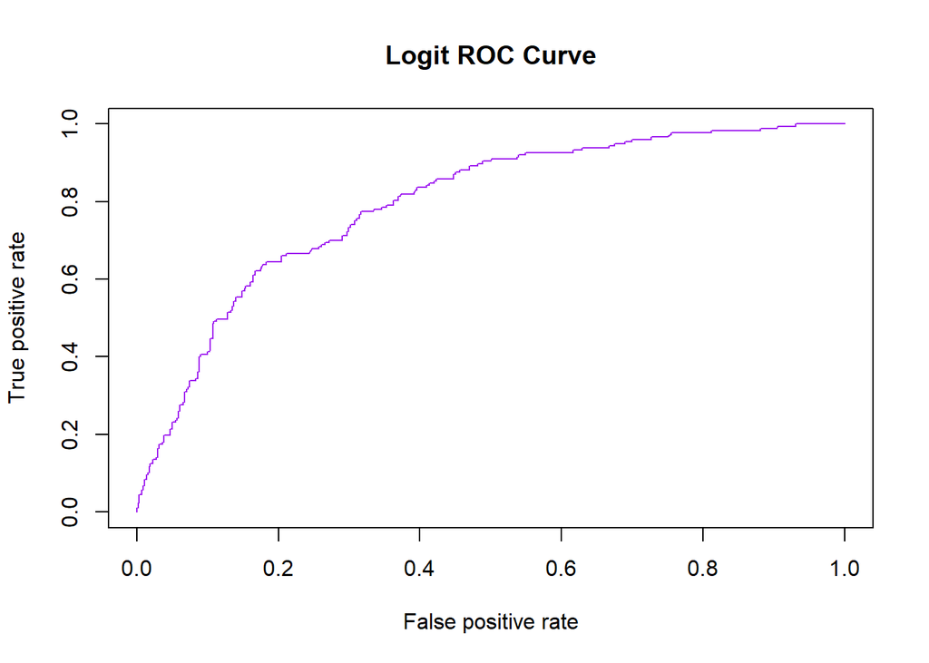

```r
pred1 <-  prediction(predict1, clase_real1)
perf1 <- performance(pred1, measure = "tpr", x.measure = "fpr")
par(mfrow = c(1,1))
plot(perf1, lty=1, col="purple", main = "Logit ROC Curve")
```

```r
auc.m1<- performance(pred1, measure = "auc", x.measure = "fpr")
auc.m1@y.values
```

```
## [[1]]
## [1] 0.7942732
```

Creamos la clase real para explicar el modelo y estimamos el modelo.3 Predecimos los valores de nuestro modelo.3 para el gobierno y realizamos la curva ROC para observar los falsos y verdaderos positivos de nuestro modelo.

Al aplicar elAUC podemos ver que nuestro modelo predice el 79.42% de la valoración al gobierno.

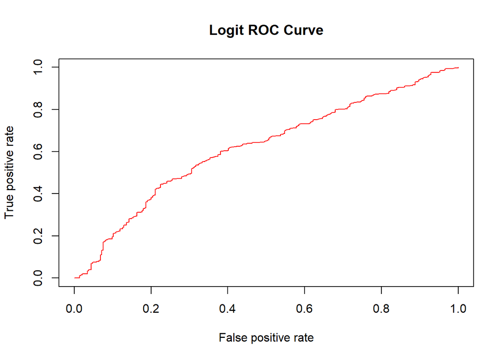

```r
clase_real2 <- test.data$opi_eje

modelo.2 <- glm(opi_eje ~ edad + hombre + ideol + clase + miedo_enf + perder_emp, data = train.data, family = "binomial")

predict2<- predict(modelo.2, newdata=test.data, type="response")

pred2 <-  prediction(predict2, clase_real2)
perf2 <- performance(pred2, measure = "tpr", x.measure = "fpr")
par(mfrow = c(1,1))
plot(perf2, lty=1, col="red", main = "Logit ROC Curve")
```

```r
auc.m2 <- performance(pred2, measure = "auc", x.measure = "fpr")
auc.m2@y.values
```

```
## [[1]]
## [1] 0.6197949
```

Hacemos lo mismo para la opinión del ejército y vemos que nuestro modelo precide el 61.97% de los casos de opinión al ejército.

[figure not shown]

```r
par(mfrow = c(1,1))
plot(perf1, lty=1, col="purple", main = "ROC Curves")
plot(perf2, lty=1, col="orange", add = TRUE)
legend(0.4, 0.6,
       c("Gobierno=0.79", "Ejército=0.61"),
       lty = c(1,1),
       bty = "n",
       col=c("purple", "red"),
       cex = 0.7)
```

## Respuesta 5 (0,5 puntos)